# DAWeek3

Robert Edwards

25 January 2019

## 1. Inroduction

Now that we are comfortable with visualizing and manipulating data in R, we can now proceed onto modelling data. The key idea behind modelling data is to infer the relationship between an:

- **outcome (or response) variable y** and
- an **explanatory (or predictor) variable x**, which can also be referred to as an **independent variable or covariate.**

Modelling can be used for two purposes:

1. **Explanation**: For describing the relationship between an outcome variable y and an explanatory variable x, and determining the potential significance of such relationships using quantifiable measures.
2. **Prediction**: for predicting the outcome variable **y** given information from one or more explanatory variables.

There are many different modelling techniques. However, we will begin with one of the easier to understand and commonly-used approaches, **linear regression**. In particular, we will start by looking at **simple linear regression**, where we only have one explanatory variable.

**Note**: Additional information and examples can be found in [Chapter 6 of An Introduction to Statistical and Data Science via R](https://moderndive.com/index.html).

## 2. Simle Linear Regression

For a response variable **y** and an explanatory variable **x**, the data can be expressed as:

$$(y_i,x_i), i=1,.,n.$$

- $y_i$ is the $i^th$ observation of the response variable;
- $\alpha$ is the **intercept** of the regression line;
- $\beta$ is the **slope** of the regression line;
- $x_i$ is the $ith$ observation of the explanatory variable; and
- $\epsilon_i$ is the $ith$ random component.

## 3. Simple Linear Regression with one Numerical Exlanatory Variable

Student feedback in higher education is extremely important when it comes to the evaluation of teaching techniques, materials, and improvements in teaching methods and technologies. However, there have been studies into potential bias factors when feedback is provided, such as the physical appearance of the teacher; see Economics of Education Review for details. Here, we shall look at a study from student evaluations of **n=463** professors from The University of Texas at Austin. In particular, we will examine the evaluation scores of the instructors based purely on one numerical variable: their beauty score. Therefore, our simple linear regression model will consist of:

the numerical outcome variable teaching score (**y**); and the numerical explanatory variable beauty score (**x**).

### Explanatory Data Analysis

Before you ever do any statistical modelling of data, you should always perform an **exploratory data analysis** of the data. Performing an exploratory data analysis can give us an idea of the distribution of the data, and whether it contains any strange values, such as **outliers** or **missing values**. However, more importantly, it is used to inform which statistical model we should fit to the data. An exploratory data analysis may involve:

1. Looking at the raw values of the data, either by looking at the spreadsheet directly, or using R.
2. By computing various summary statistics, such as the five-number summary, means, and standard deviations.
3. Plotting the data using various data visualization techniques.

Let’s examine the data evals. We can look at the raw values from evals using the RStudio pop-up spreadsheet viewer using:

```r
View(evals)
```

```r
head(evals)
```

```
## # A tibble: 6 x 13
##      ID score   age bty_avg gender ethnicity   language rank    pic_outfit
##   <int> <dbl> <int>   <dbl> <fct>  <fct>       <fct>    <fct>   <fct>
## 1     1  4.70    36      5. female minority    english  tenure~ not formal
## 2     2  4.10    36      5. female minority    english  tenure~ not formal
## 3     3  3.90    36      5. female minority    english  tenure~ not formal
## 4     4  4.80    36      5. female minority    english  tenure~ not formal
## 5     5  4.60    59      3. male   not minori~ english  tenured not formal
## 6     6  4.30    59      3. male   not minori~ english  tenured not formal
## # ... with 4 more variables: pic_color <fct>, cls_did_eval <int>,
## #   cls_students <int>, cls_level <fct>
```

```r
nrow(evals)
```

```
## [1] 463
```

At the moment we are only really interested in the instructors teaching (score) and beauty (bty_avg) scores, and so we can look at a subset of the data as follows:

```r
evals.scores <- evals %>%
  select(score, bty_avg)
```

**Task**: Create a new object evals.10cases by replace the select function with the sample_n function to look at a random subset of 10 instructors.

```r
evals.10cases <- evals %>%
  sample_n(10)
```

The outcome variable *score* is a numerical average of the average teaching score based on students’ evaluations between 1 and 5. The explanatory variable *bty_avg* is the numerical variable of the average beauty score from a panel of six students’ scores between 1 and 10. As both variables are numerical, we can produce graphical summaries using boxplots and numerical summaries by calculating summary statistics using the *skim* function from the *skimr* package as follows:

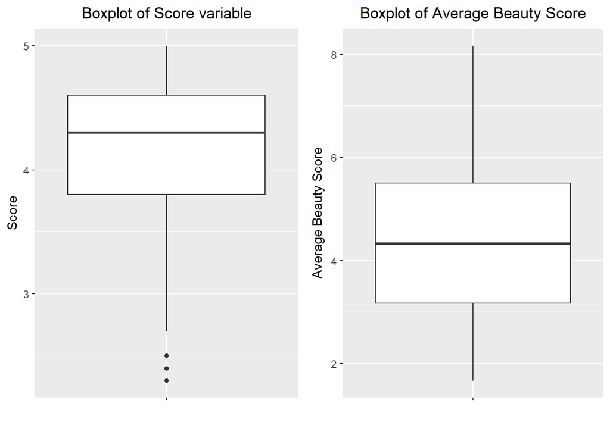

```r
score.boxplot <- ggplot(evals.scores, aes(x = "", y = score)) +
  geom_boxplot() +
  labs(x = "", y = "Score",
       title = "Boxplot of Score variable")+
        theme(plot.title = element_text(hjust = 0.5))
        #This function centres the plot title

bty_avg.boxplot <- ggplot(evals.scores, aes(x = "", y = bty_avg)) +
  geom_boxplot() +
  labs(x = "", y = "Average Beauty Score",
       title = "Boxplot of Average Beauty Score")+
        theme(plot.title = element_text(hjust = 0.5))
        #This function centres the plot title

grid.arrange(score.boxplot, bty_avg.boxplot, ncol=2)
```

```r
# This function shows the 2 plots side by side
```

```r
evals.scores %>%
  skim()
```

```
## Skim summary statistics
##  n obs: 463
##  n variables: 2
##
## Variable type: numeric
##  variable missing complete   n mean   sd   p0  p25 median p75 p100
##   bty_avg       0      463 463 4.42 1.53 1.67 3.17   4.33 5.5 8.17
##     score       0      463 463 4.17 0.54 2.3  3.8    4.3  4.6 5
##      hist
##  ▂▅▅▇▃▃▂▁
##  ▁▁▂▃▅▇▇▆
```

- *missing*: the number of missing values.
- *complete*: the number of non-missing values.
- *n*: the total number of observations.
- *mean*: the mean or average.
- *sd*: the standard deviation.
- *p0*: the $0th$ percentile: the value at which 0% of values are smaller than it (i.e. the minimum).
- *p25*: the $25th$ percentile: the value at which 25% of values are smaller than it (i.e. the 1st quartile).
- *p50*: the $50th$ percentile: the value at which 50% of values are smaller than it (i.e. the median).
- *p75*: the $75th$ percentile: the value at which 75% of values are smaller than it (i.e. the 3rd quartile).
- *p100*: the $100th$ percentile: the value at which 100% of values are smaller than it (i.e. the maximum).
- hist: provides a snapshot of a histogram of the variable.

These summary statistics give us an idea of how both variables are distributed. For example, the mean teaching score (*score*) is 4.17 out 5, while the mean beauty score (*bty_avg*) is 4.42 out of 10. Also, the middle 50% of the data for *score* lies between 3.8 and 4.6, while the middle 50% of *bty_avg* lies between 3.17 and 5.5.

### Correlation

The above summary statistics provide information about each variable separately. However, we are interested in a potential relationship between the two variables and as such it would be of interest to evaluate some statistic that considers both variables simultaneously. One such statistic is the **correlation**, which ranges between -1 and 1 and describes the strength of the linear relationship between two numerical variables, such that

-1 indicates a perfect *negative relationship*. That is, as the values of one variable increase, the values of the other decrease. 0 indicates no relationship. The values of both variables increase/decrease independently of one another. 1 indicates a perfect *positive relationship*. That is, the values of both variables increase simultaneously.

The correlation coefficient can be computed in R using the `get_correlation` function from the moderndive package. The function requires two numerical variables separated by ~ (or ‘tilde’), much like the formula syntax, such that the outcome variable score is put on the left-hand-side of the formula, and the explanatory variable bty_avg is placed on the right-hand-side of the formula: